# World Happiness

Aaron Chien and Dorris Wu

2022-10-01

[output not shown]

## Introduction

Hello, in the project by Aaron Chien and Dorris Wu, we will be exploring the dataset of world happiness from Kaggle exploring different variables and their effects on happiness. Each variable has a value from 0 to 10 where 0 is the worst and 10 is the best base on public polls. The dataset can be found here: [world happiness data](https://www.kaggle.com/datasets/unsdsn/world-happiness).

## Section 1

```r
world_happiness <- read.csv("world_happiness.csv")
```

```r
colnames(world_happiness) <- c("Rank", "Country", "Score", "GDP", "Support", "Health", "Freedom", "Generosity", "Corruption")
```

To understand the data better when coding, I will be renaming some of these column names: overall rank - Rank, Country or region - Country, Score - Score, GDP per capita - GDP, Social support - Support, Healthy life expectancy - Health, Freedom to make life choices - Freedom, Generosity - Generosity, Perceptions of corruption - Corruption.

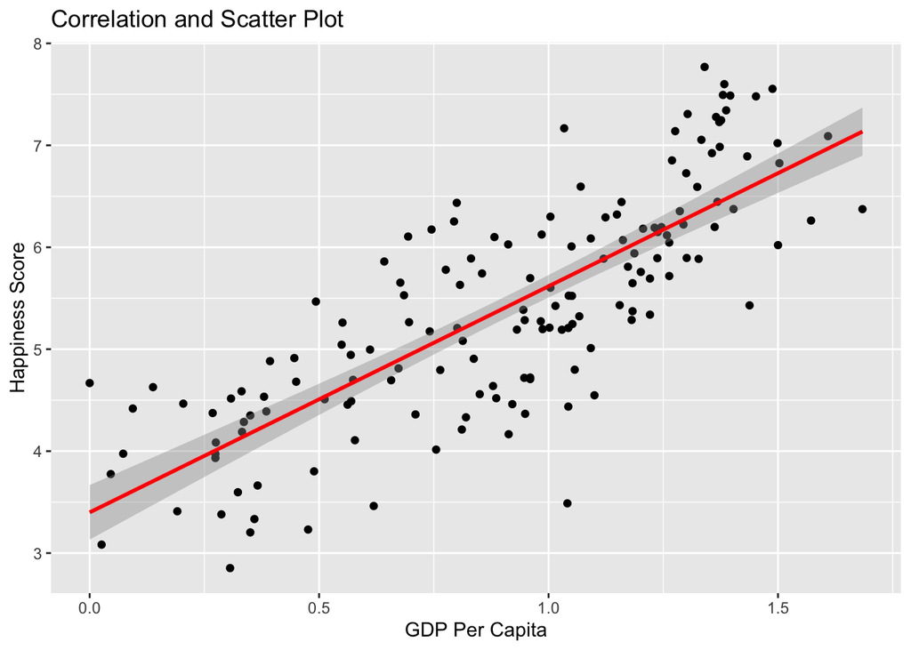

```r
world_happiness %>%
  ggplot(mapping = aes(x = GDP, y = Score)) +
  geom_point() +
  geom_smooth(formula = y ~ x, method = lm, se = T, col = "red") +
  labs(title = "Correlation and Scatter Plot",
       x = "GDP Per Capita",
       y = "Happiness Score")
```

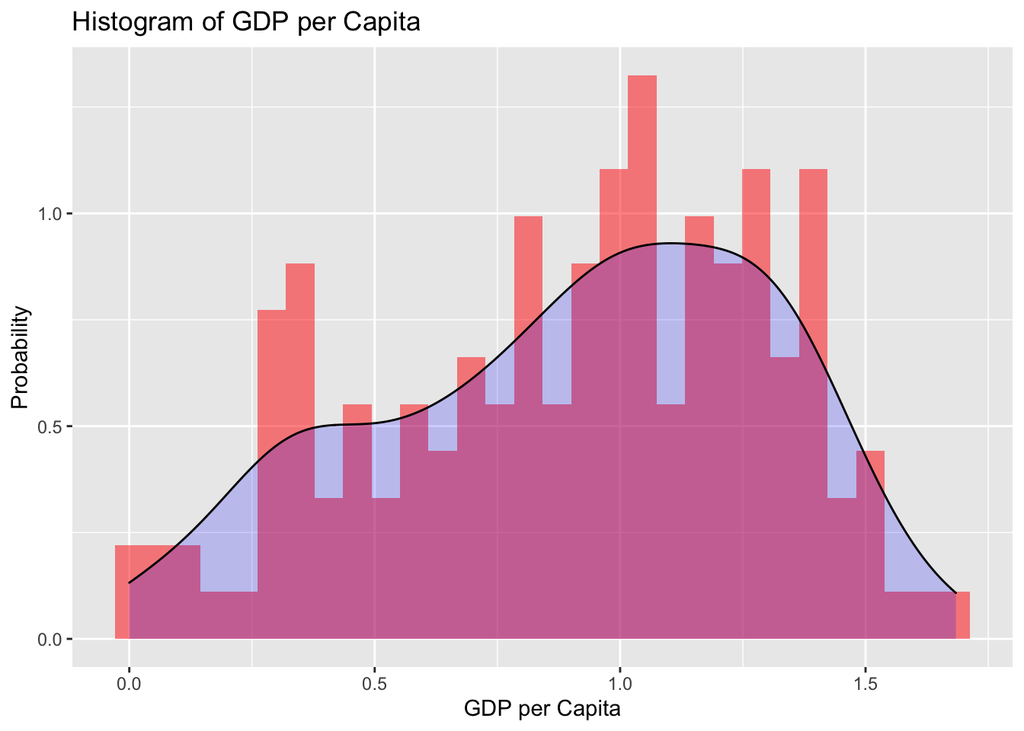

```r
world_happiness %>%
  ggplot(mapping = aes(x = GDP)) +
  geom_histogram(aes(y = ..density..), fill = "red", alpha = 0.5,
                 bins = 30) +
  geom_density(fill = "blue", alpha = 0.2) +
  labs(title = "Histogram of GDP per Capita",
       x = "GDP per Capita",
       y = "Probability")
```

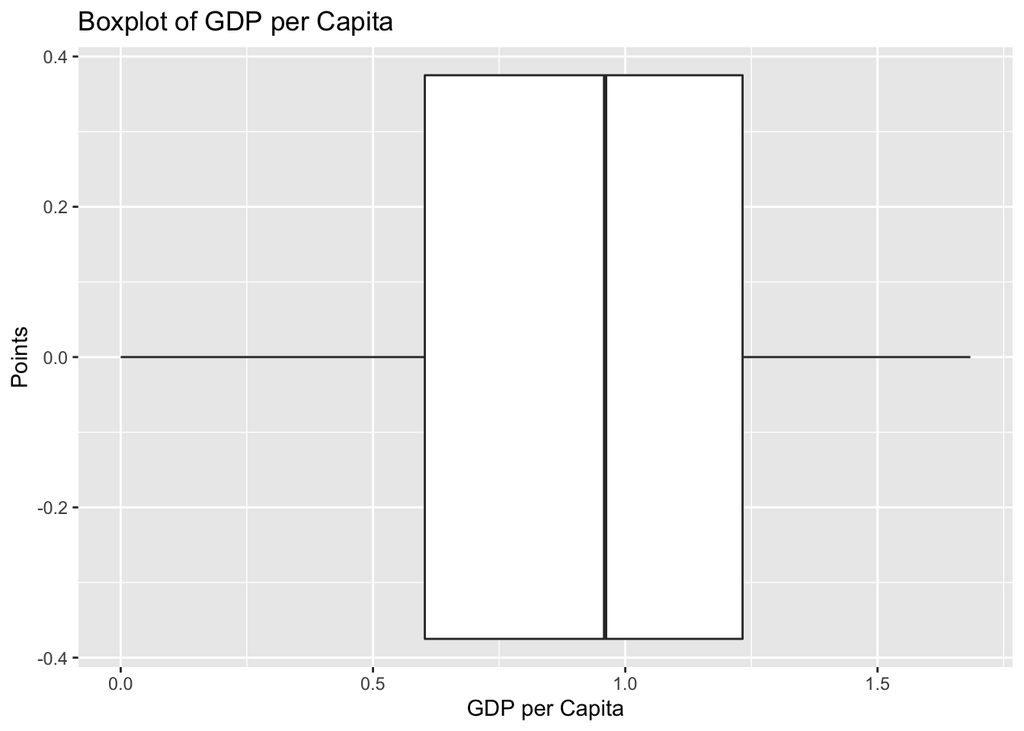

```r
world_happiness %>%
  ggplot(mapping = aes(x = GDP)) +
  geom_boxplot() +
  labs(title = "Boxplot of GDP per Capita",
       x = "GDP per Capita",
       y = "Points")
```

```r
summary(world_happiness$GDP)
```

```
##    Min. 1st Qu.  Median    Mean 3rd Qu.    Max.
##  0.0000  0.6028  0.9600  0.9051  1.2325  1.6840
```

Examining GDP per capita first, we can see that the data is a bit left-skewed and that there are no outliers in the boxplot. The skewness is speaking out to me as we can see that most of the data does not lie with the mean. However, I do think the skewness is not that big and we can continue on. The regression line also seems to fit in well with the actual score, indicating that world happiness is correlated with GDP per capita.

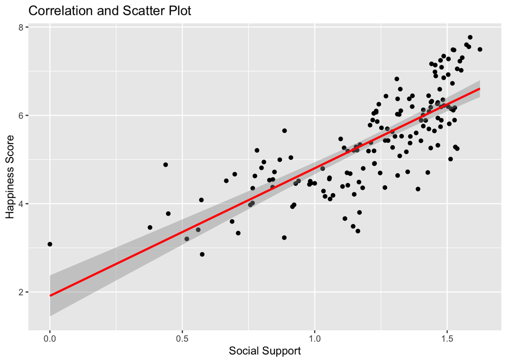

```r
world_happiness %>%
  ggplot(mapping = aes(x = Support, y = Score)) +
  geom_point() +
  geom_smooth(formula = y ~ x, method = lm, se = T, col = "red") +
  labs(title = "Correlation and Scatter Plot",
       x = "Social Support",
       y = "Happiness Score")
```

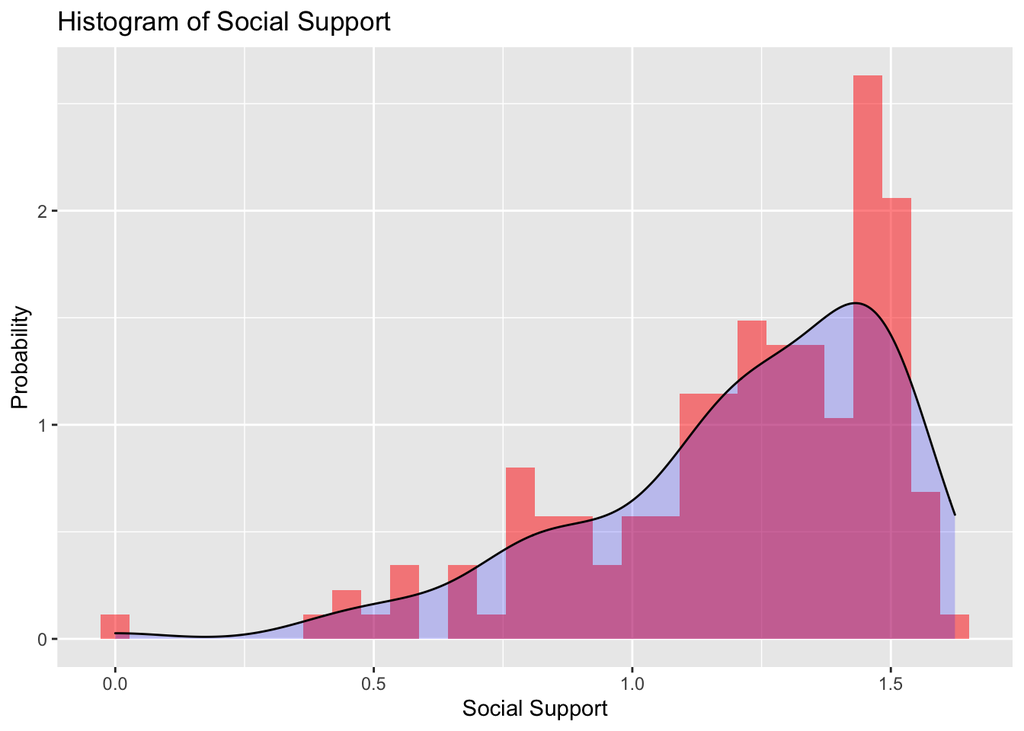

```r
world_happiness %>%
  ggplot(mapping = aes(x = Support)) +
  geom_histogram(aes(y = ..density..), fill = "red", alpha = 0.5,
                 bins = 30) +
  geom_density(fill = "blue", alpha = 0.2) +
  labs(title = "Histogram of Social Support",
       x = "Social Support",
       y = "Probability")
```

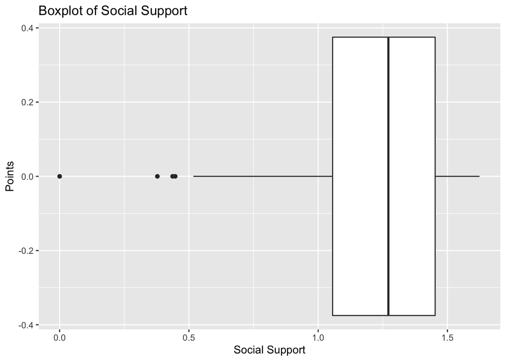

```r
world_happiness %>%
  ggplot(mapping = aes(x = Support)) +
  geom_boxplot() +
  labs(title = "Boxplot of Social Support",
       x = "Social Support",
       y = "Points")
```

```r
summary(world_happiness$Support)
```

```
##    Min. 1st Qu.  Median    Mean 3rd Qu.    Max.
##   0.000   1.056   1.272   1.209   1.452   1.624
```

Here, we see that social support is heavily left-skewed and has many outliers, these outliers can pose a problem which is why we will be getting rid of them later on. But looking at the regression line against the score, we can see that they are a bit correlated, so social support may also be an important predictor in world happiness.

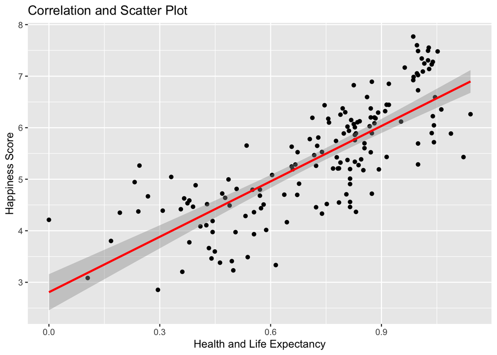

```r
world_happiness %>%
  ggplot(mapping = aes(x = Health, y = Score)) +
  geom_point() +
  geom_smooth(formula = y ~ x, method = lm, se = T, col = "red") +
  labs(title = "Correlation and Scatter Plot",
       x = "Health and Life Expectancy",
       y = "Happiness Score")
```

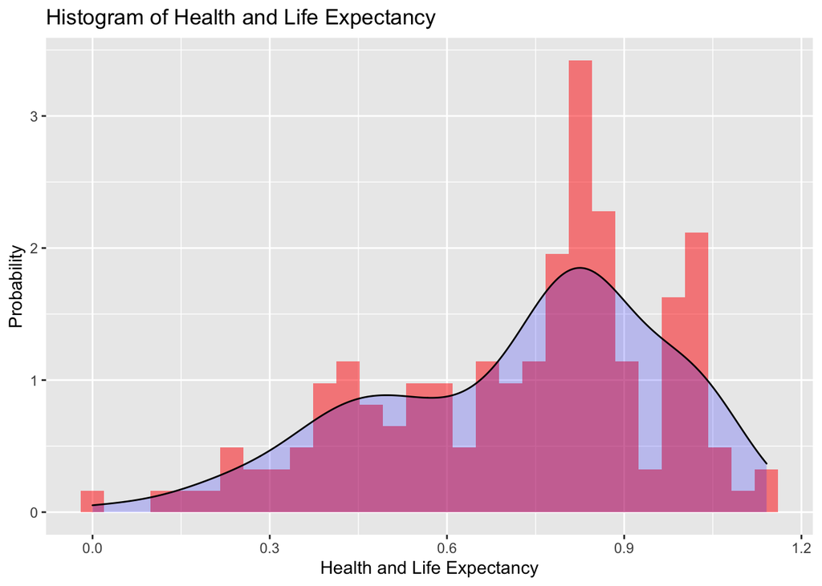

```r
world_happiness %>%
  ggplot(mapping = aes(x = Health)) +
  geom_histogram(aes(y = ..density..), fill = "red", alpha = 0.5,
                 bins = 30) +
  geom_density(fill = "blue", alpha = 0.2) +
  labs(title = "Histogram of Health and Life Expectancy",
       x = "Health and Life Expectancy",
       y = "Probability")
```

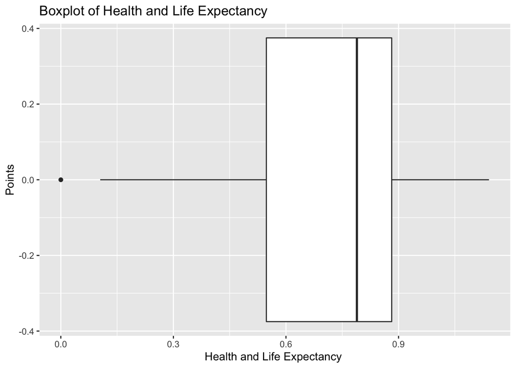

```r
world_happiness %>%
  ggplot(mapping = aes(x = Health)) +
  geom_boxplot() +
  labs(title = "Boxplot of Health and Life Expectancy",
       x = "Health and Life Expectancy ",
       y = "Points")
```

```r
summary(world_happiness$Health)
```

```
##    Min. 1st Qu.  Median    Mean 3rd Qu.    Max.
##  0.0000  0.5477  0.7890  0.7252  0.8818  1.1410
```

Here, life expectancy has two peaks and has one outlier. This may be problematic as it may skewed the data, so we may have to use life expectancy as the cause of hetereoskedascity in the model if hetereoskedascity is present. However, the score of happiness and life expectancy do seem to be correlated so this may be another predictor that needs to be included in the model.

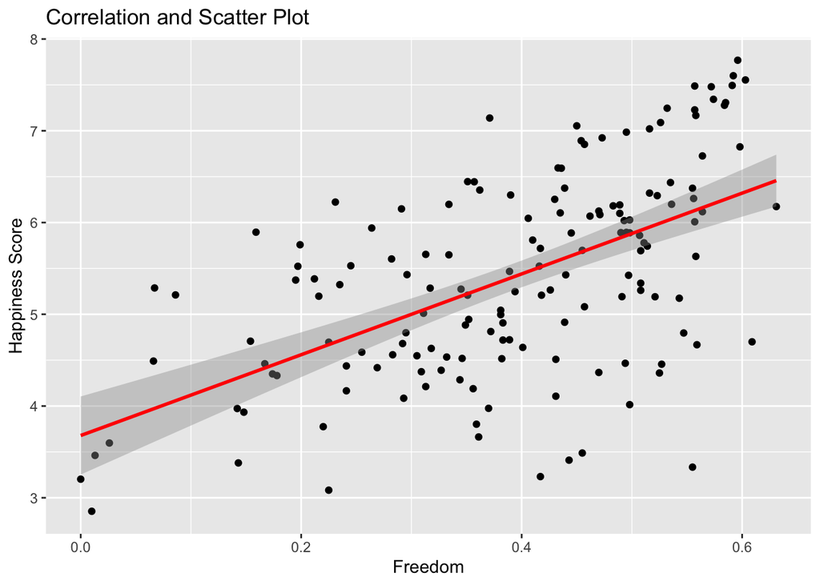

```r
world_happiness %>%
  ggplot(mapping = aes(x = Freedom, y = Score)) +
  geom_point() +
  geom_smooth(formula = y ~ x, method = lm, se = T, col = "red") +
  labs(title = "Correlation and Scatter Plot",
       x = "Freedom",
       y = "Happiness Score")
```

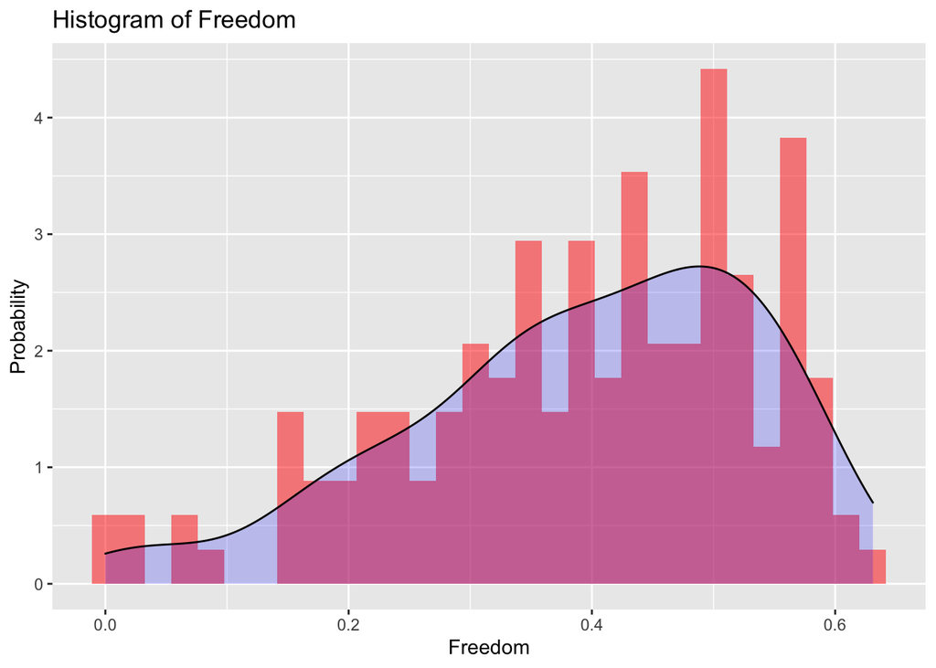

```r
world_happiness %>%
  ggplot(mapping = aes(x = Freedom)) +
  geom_histogram(aes(y = ..density..), fill = "red", alpha = 0.5,
                 bins = 30) +
  geom_density(fill = "blue", alpha = 0.2) +
  labs(title = "Histogram of Freedom",
       x = "Freedom",
       y = "Probability")
```

[figure not shown]

```r
world_happiness %>%
  ggplot(mapping = aes(x = GDP)) +
  geom_boxplot() +
  labs(title = "Boxplot of Freedom",
       x = "Freedom",
       y = "Points")
```

```r
summary(world_happiness$Freedom)
```

```
##    Min. 1st Qu.  Median    Mean 3rd Qu.    Max.
##  0.0000  0.3080  0.4170  0.3926  0.5072  0.6310
```

In the freedom variable, we can see that there is a strong correlation between happiness and the freedom to make choices. Examining further into the histogram, we see that it is skewed the to left, meaning that most of the data lies in the median rather than the mean.

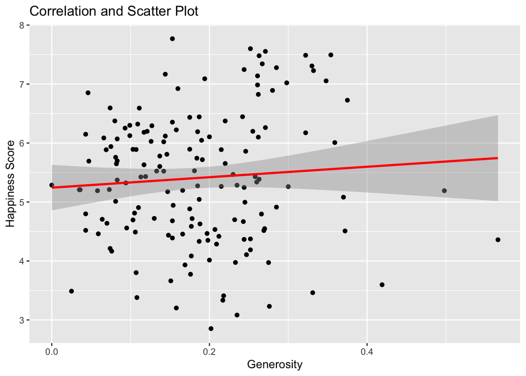

```r
world_happiness %>%
  ggplot(mapping = aes(x = Generosity, y = Score)) +
  geom_point() +
  geom_smooth(formula = y ~ x, method = lm, se = T, col = "red") +
  labs(title = "Correlation and Scatter Plot",
       x = "Generosity",
       y = "Happiness Score")
```

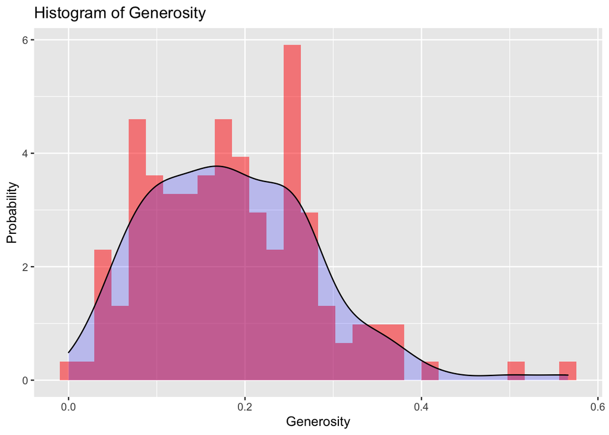

```r
world_happiness %>%
  ggplot(mapping = aes(x = Generosity)) +
  geom_histogram(aes(y = ..density..), fill = "red", alpha = 0.5,
                 bins = 30) +
  geom_density(fill = "blue", alpha = 0.2) +
  labs(title = "Histogram of Generosity",
       x = "Generosity",
       y = "Probability")
```

[figure not shown]

```r
world_happiness %>%
  ggplot(mapping = aes(x = GDP)) +
  geom_boxplot() +
  labs(title = "Boxplot of Generosity",
       x = "Generosity",
       y = "Points")
```

```r
summary(world_happiness$Generosity)
```

```
##    Min. 1st Qu.  Median    Mean 3rd Qu.    Max.
##  0.0000  0.1087  0.1775  0.1848  0.2482  0.5660
```

Examining generosity, we can see that it is heavily skewed to the right and we also have a few outliers that we may need to remove in order to gain a better model and there also seems to be more variance of the score against the regression line. The regression line is very flat, so generosity may not be the best predictor variable to use here.

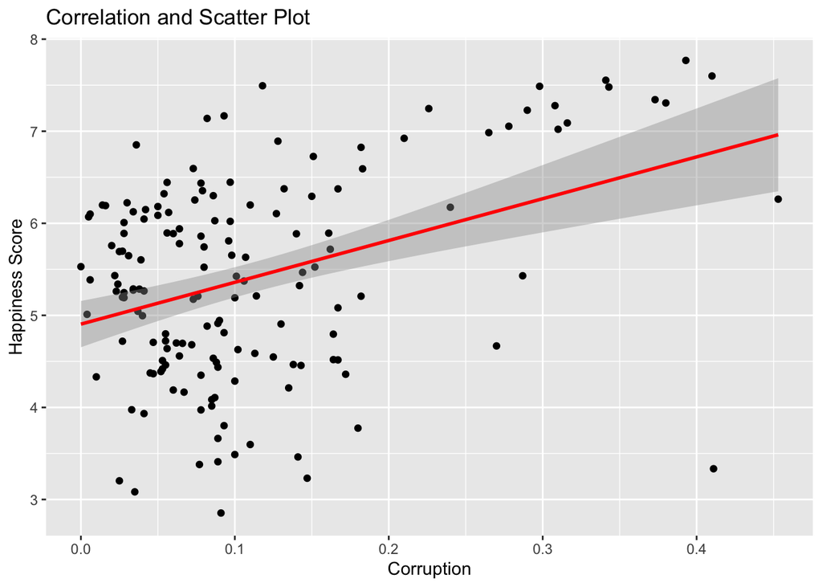

```r
world_happiness %>%
  ggplot(mapping = aes(x = Corruption, y = Score)) +
  geom_point() +
  geom_smooth(formula = y ~ x, method = lm, se = T, col = "red") +
  labs(title = "Correlation and Scatter Plot",
       x = "Corruption",
       y = "Happiness Score")
```

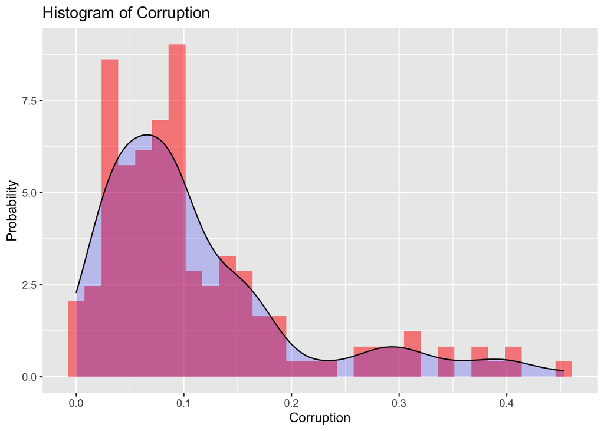

```r
world_happiness %>%
  ggplot(mapping = aes(x = Corruption)) +
  geom_histogram(aes(y = ..density..), fill = "red", alpha = 0.5,
                 bins = 30) +
  geom_density(fill = "blue", alpha = 0.2) +
  labs(title = "Histogram of Corruption",
       x = "Corruption",
       y = "Probability")
```

[figure not shown]

```r
world_happiness %>%
  ggplot(mapping = aes(x = GDP)) +
  geom_boxplot() +
  labs(title = "Boxplot of Corruption",
       x = "Corruption",
       y = "Points")
```

```r
summary(world_happiness$Corruption)
```

```
##    Min. 1st Qu.  Median    Mean 3rd Qu.    Max.
##  0.0000  0.0470  0.0855  0.1106  0.1412  0.4530
```

Perceptions of corruption is heavily skewed and we also see in the regression line that there is some correlation, but a lot of the data is scattered towards low levels of corruption. This variable would need to be explored more because the regression line is showing correlation, but there’s a high cluster of the scores towards the levels of 0 to 0.2 of corruption.

## Section 2

To start off, we create a base model to work from where Score is the dependent variable base on social support, health and life expectancy, freedom to make choices, generosity, and perceptions of world corruption.

```r
wh_reg <- lm(Score ~ GDP + Support + Health + Freedom +
               Generosity + Corruption, data = world_happiness)

stargazer(wh_reg, type = "text")
```

```
##
## ===============================================
##                         Dependent variable:
##                     ---------------------------
##                                Score
## -----------------------------------------------
## GDP                          0.775***
##                               (0.218)
##
## Support                      1.124***
##                               (0.237)
##
## Health                       1.078***
##                               (0.335)
##
## Freedom                      1.455***
##                               (0.375)
##
## Generosity                     0.490
##                               (0.498)
##
## Corruption                    0.972*
##                               (0.542)
##
## Constant                     1.795***
##                               (0.211)
##
## -----------------------------------------------
## Observations                    156
## R2                             0.779
## Adjusted R2                    0.770
## Residual Std. Error      0.534 (df = 149)
## F Statistic           87.618*** (df = 6; 149)
## ===============================================
## Note:               *p<0.1; **p<0.05; ***p<0.01
```

```r
support <- world_happiness$Support
health <- world_happiness$Health
freedom <- world_happiness$Freedom
gen <- world_happiness$Generosity
corrupt <- world_happiness$Corruption

outliers <- c(which(support %in% boxplot.stats(support)$out),
              which(health %in% boxplot.stats(health)$out),
              which(freedom %in% boxplot.stats(freedom)$out),
              which(gen %in% boxplot.stats(gen)$out),
              which(corrupt %in% boxplot.stats(corrupt)$out))

world_happiness_cl <- world_happiness[-outliers, ]
```

Removing outliers and creating a new regression line.

```r
wh_reg2 <- lm(Score ~ GDP + Support + Health + Freedom +
                              Generosity + Corruption,
                              data = world_happiness_cl)

stargazer(wh_reg2, type = "text")
```

```
##
## ===============================================
##                         Dependent variable:
##                     ---------------------------
##                                Score
## -----------------------------------------------
## GDP                          0.709***
##                               (0.225)
##
## Support                      1.196***
##                               (0.261)
##
## Health                       1.183***
##                               (0.357)
##
## Freedom                      1.391***
##                               (0.372)
##
## Generosity                    0.928*
##                               (0.556)
##
## Corruption                     1.135
##                               (0.832)
##
## Constant                     1.618***
##                               (0.259)
##
## -----------------------------------------------
## Observations                    134
## R2                             0.740
## Adjusted R2                    0.728
## Residual Std. Error      0.503 (df = 127)
## F Statistic           60.324*** (df = 6; 127)
## ===============================================
## Note:               *p<0.1; **p<0.05; ***p<0.01
```

The new equation after removing the outliers is:
$$Score = 1.618 + 0.709 \times GDP + 1.196
\times Support + 1.183 \times Health + 1.391 \times Freedom + 0.928
\times Generosity + 1.135 \times Corruption$$

## 4

```r
ss <- regsubsets(Score ~ GDP + Support + Health + Freedom +
                         Generosity + Corruption,
                         method = c("exhaustive"), nbest = 3,                                 data = world_happiness_cl)
```

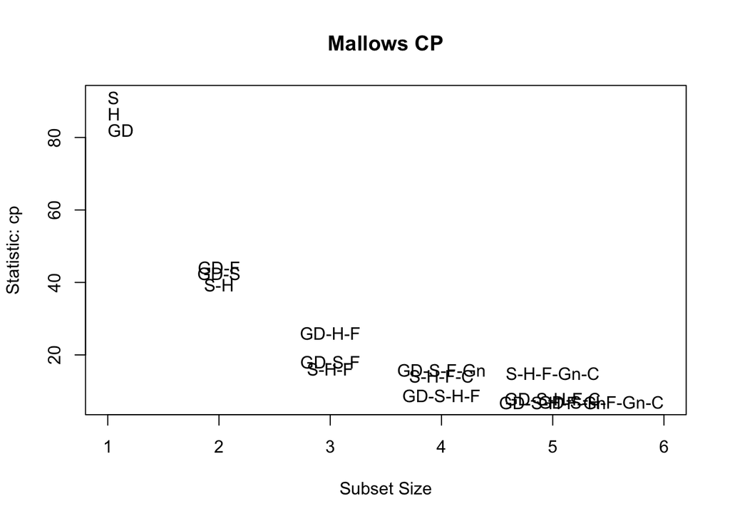

```
##            Abbreviation
## GDP                  GD
## Support               S
## Health                H
## Freedom               F
## Generosity           Gn
## Corruption            C
```

```r
subsets(ss, statistic = "cp", legend = F, main = "Mallows CP")
```

```r
library(olsrr)
possibilites <- ols_step_all_possible(wh_reg2)
possibilites[c(42, 57, 58, 63), ]
```

```
##    Index N                                       Predictors  R-Square
## 42    42 4                       GDP Support Health Freedom 0.7284859
## 57    57 5            GDP Support Health Freedom Generosity 0.7364510
## 58    58 5            GDP Support Health Freedom Corruption 0.7345501
## 63    63 6 GDP Support Health Freedom Generosity Corruption 0.7402568
##    Adj. R-Square Mallow's Cp
## 42     0.7200668    8.755351
## 57     0.7261561    6.860846
## 58     0.7241810    7.790261
## 63     0.7279855    7.000000
```

Examining the Mallows CP graph, although difficult to point out, we can see that the lowest score is GD - S - H - F - Gn, meaning that we should be adding these variables in our model.

[output not shown]

[output not shown]

[output not shown]

[output not shown]

[output not shown]

[output not shown]

[output not shown]

[output not shown]

## Section 5

```r
vif(wh_reg2)
```

```
##        GDP    Support     Health    Freedom Generosity Corruption
##   3.679138   2.300507   3.237709   1.301888   1.192665   1.177559
```

The VIF score is relatively small for all of my variables, so I am deciding to keep them. However, GDP and Health are the largest, but since they are not near a score of 5, I do not believe I need to change my equation.

## Section 6

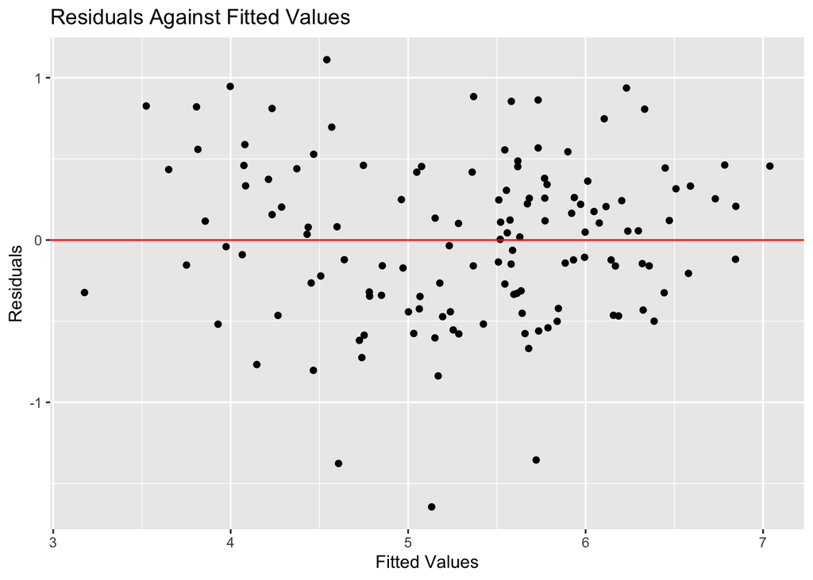

```r
residuals_plot <- data_frame(Residuals = wh_reg2$residuals,
                             Fitted_values = wh_reg2$fitted.values)
residuals_plot %>%
  ggplot(mapping = aes(x = Fitted_values, y = Residuals)) +
  geom_point() +
  geom_hline(yintercept = 0, color = "red") +
  labs(x = "Fitted Values",
      y = "Residuals",
      title = "Residuals Against Fitted Values")
```

The residuals do not appear to follow a function, so I do not believe there are any forms of hetereoskedascity present, but testing shall double check this.

## Section 7

```r
resettest(formula = wh_reg2, power = 2, type = "fitted")
```

```
##
##  RESET test
##
## data:  wh_reg2
## RESET = 10.887, df1 = 1, df2 = 126, p-value = 0.001259
```

$$Score = 1.618 + 0.709 \times GDP
+ 1.196 \times Support + 1.183 \times Health + 1.391 \times Freedom +
0.928 \times Generosity + 1.135 \times Corruption + \beta \times
Score^2$$

We reject the null that the $\beta$ for Score^2 is 0, so there is at least an interaction between two variables.

```r
AIC(wh_reg2)
```

```
## [1] 204.7837
```

```r
BIC(wh_reg2)
```

```
## [1] 227.9664
```

When creating different models, we can compare the different models to the AIC and BIC of wh_reg2 to have a sense of which model is the best.

```r
wh_reset_model <- lm(Score ~ GDP + Support  + Health + Freedom + I(Support * Health), data = world_happiness_cl)

summary(wh_reset_model)
```

```
##
## Call:
## lm(formula = Score ~ GDP + Support + Health + Freedom + I(Support *
##     Health), data = world_happiness_cl)
##
## Residuals:
##      Min       1Q   Median       3Q      Max
## -1.61711 -0.22222 -0.00931  0.27430  1.19022
##
## Coefficients:
##                     Estimate Std. Error t value Pr(>|t|)
## (Intercept)           4.8328     0.6369   7.588 5.90e-12 ***
## GDP                   0.6672     0.2051   3.254 0.001458 **
## Support              -1.5758     0.5924  -2.660 0.008811 **
## Health               -3.5287     1.0047  -3.512 0.000615 ***
## Freedom               1.6700     0.3214   5.197 7.78e-07 ***
## I(Support * Health)   4.0916     0.8209   4.984 1.98e-06 ***
## ---
## Signif. codes:  0 '***' 0.001 '**' 0.01 '*' 0.05 '.' 0.1 ' ' 1
##
## Residual standard error: 0.4685 on 128 degrees of freedom
## Multiple R-squared:  0.7726, Adjusted R-squared:  0.7637
## F-statistic: 86.98 on 5 and 128 DF,  p-value: < 2.2e-16
```

## Section 8

```r
gqtest(wh_reset_model, fraction = 0.20, alternative = "greater",
       order.by = ~ GDP + Support + Health + Freedom +
       I(Support * Health), data = world_happiness_cl)
```

```
##
##  Goldfeld-Quandt test
##
## data:  wh_reset_model
## GQ = 0.57986, df1 = 48, df2 = 47, p-value = 0.9685
## alternative hypothesis: variance increases from segment 1 to 2
```

According to the GQ test, our p value is EXTREMELY high, meaning that we fail to reject the null so our data is relatively homoskedastic.

```r
wh_reset_summ <- summary(wh_reset_model)

N <- nrow(world_happiness_cl)
resid_sq <- (wh_reset_summ$residuals)^2
world_happiness_cl$resid_sq <- resid_sq

wh_resid <- lm(resid_sq ~ GDP + Support + Health + Freedom +
                          I(Support * Health),
                          data = world_happiness_cl)
```

```r
qchisq(0.95, 6 - 1)
```

```
## [1] 11.0705
```

```r
N * summary(wh_resid)$r.squared
```

```
## [1] 3.934106
```

Using the BP test on the full mode, we see that the BP value is NOT greater than the chi square test, so we fail to reject the null that it is homoskedastic.

```r
GDP_BP <- lm(resid_sq ~ world_happiness_cl$GDP)

Support_BP <- lm(resid_sq ~ world_happiness_cl$Support)

Health_BP <- lm(resid_sq ~ world_happiness_cl$Health)

Freedom_BP <- lm(resid_sq ~ world_happiness_cl$Freedom)

Support_Health_BP <- lm(resid_sq ~ I(world_happiness_cl$Support *
                                    world_happiness_cl$Health))
```

I decided to go with individual BP tests on each variable so I can better examine which variable is causing heteroskedascity if any exists.

```r
qchisq(0.95, 2 - 1)
```

```
## [1] 3.841459
```

```r
N * summary(GDP_BP)$r.squared
```

```
## [1] 0.8104497
```

```r
N * summary(Support_BP)$r.squared
```

```
## [1] 2.115717
```

```r
N * summary(Health_BP)$r.squared
```

```
## [1] 1.319235
```

```r
N * summary(Freedom_BP)$r.squared
```

```
## [1] 0.5171469
```

```r
N * summary(Support_Health_BP)$r.squared
```

```
## [1] 1.822997
```

We see that none of our variables are greater than the chisq, so our data is relatively homoskedastic.

## Section 9

```r
AIC(wh_reg)
```

```
## [1] 255.5295
```

```r
BIC(wh_reg)
```

```
## [1] 279.9284
```

The AIC and BIC are well above 200, which is really high. But let’s examine our other model.

```r
AIC(wh_reg2)
```

```
## [1] 204.7837
```

```r
BIC(wh_reg2)
```

```
## [1] 227.9664
```

Removing the outliers helped improve our model, but the AIC and BIC score is still quite high.

```r
AIC(wh_reset_model)
```

```
## [1] 184.9556
```

```r
BIC(wh_reset_model)
```

```
## [1] 205.2404
```

This model has an AIC and BIC score that is less than our original model, indicating a better fit and predictor.

## Section 9

```r
stargazer(wh_reset_model, type = "text")
```

```
##
## ===============================================
##                         Dependent variable:
##                     ---------------------------
##                                Score
## -----------------------------------------------
## GDP                          0.667***
##                               (0.205)
##
## Support                      -1.576***
##                               (0.592)
##
## Health                       -3.529***
##                               (1.005)
##
## Freedom                      1.670***
##                               (0.321)
##
## I(Support * Health)          4.092***
##                               (0.821)
##
## Constant                     4.833***
##                               (0.637)
##
## -----------------------------------------------
## Observations                    134
## R2                             0.773
## Adjusted R2                    0.764
## Residual Std. Error      0.469 (df = 128)
## F Statistic           86.984*** (df = 5; 128)
## ===============================================
## Note:               *p<0.1; **p<0.05; ***p<0.01
```

Our final model is
$$Score = 4.833 + 0.667
\times GDP + -1.576 \times Support + -3.529 \times Health + 1.670 \times
Freedom + 4.092 \times Support \times Health$$

The F stats has a p value that is extremely small, so all the coefficients are significant enough and not 0. The R^2 is also 0.773 so 77.30% of the score is explained by the model itself, which is a majority and I am satisfied with that. The standard errors for each coefficient is quite small, meaning that the coefficient for each variable would not differ too much. For GDP, an increase in the score increases the happiness by 0.667 and increase in the score for freedom increases happiness by 1.670. Since Support and Health have an interaction, an increase in the Support score increases happiness by $-1.576 + 4.092 \times Health$ and an increase in the Health score increases happiness by $-3.529 + 4.092 \times Support$.

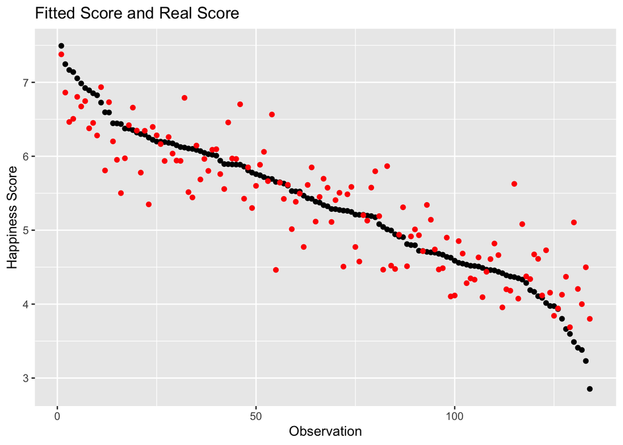

```r
results <- data.frame(Row = 1:N,
                      Score = (world_happiness_cl$Score),
                      Predicted = (wh_reset_model$fitted.values))

results %>%
  ggplot(aes(Row)) +
  geom_point(aes(y = Score)) +
  geom_point(aes(y = Predicted), col = "red") +
  labs(title = "Fitted Score and Real Score",
       x = "Observation",
       y = "Happiness Score") +
  scale_color_manual(breaks=c('Observation', 'Fitted'),
                     values=c('Observation'='black',
                              'Fitted'='red'))
```

As you can see, they both follow along the same trend and path, but of course there are some residuals as in the world of data science, it is very difficult to find the true parameters and true equations, but we can do our best to estimate it as close as possible.